# Introduction to Linear Models

January 27, 2021

## Data for Today

The `ncbirths` dataset is a random sample of 1,000 cases taken from a larger dataset collected in North Carolina in 2004.

Each case describes the birth of a single child born in North Carolina, along with various characteristics of the child (e.g. birth weight, length of gestation, etc.), the child’s mother (e.g. age, weight gained during pregnancy, smoking habits, etc.) and the child’s father (e.g. age).

**What do you expect the dataset would look like?**

## Relationships Between Variables

- In a statistical model, we generally have one variable that is the output and one or more variables that are the inputs.
- Response variable
  - a.k.a. \(y\), dependent
  - The quantity you want to understand
- Explanatory variable
  - a.k.a. \(x\), independent, explanatory, predictor
  - Something you think might be related to the response
- Both variables are numerical

## Linear Regression

- Assume the relationship between \(x\) and \(y\) takes the form of a linear function.

\[ response = intercept + slope \cdot explanatory + noise \]

- Population Regression Model

\[ y_i = \beta_0 + \beta_1 \cdot X + \epsilon_i \,, \qquad \epsilon \sim N(0, \sigma) \]

- Fitted Regression Model

\[ \hat{y} = b_0 + b_1 \cdot x_i \]

## Visualizing Linear Regression

- The scatterplot has been called the most “generally useful invention in the history of statistical graphics.”
- It is a simple two-dimensional plot in which the two coordinates of each dot represent the values of two variables measured on a single observation.

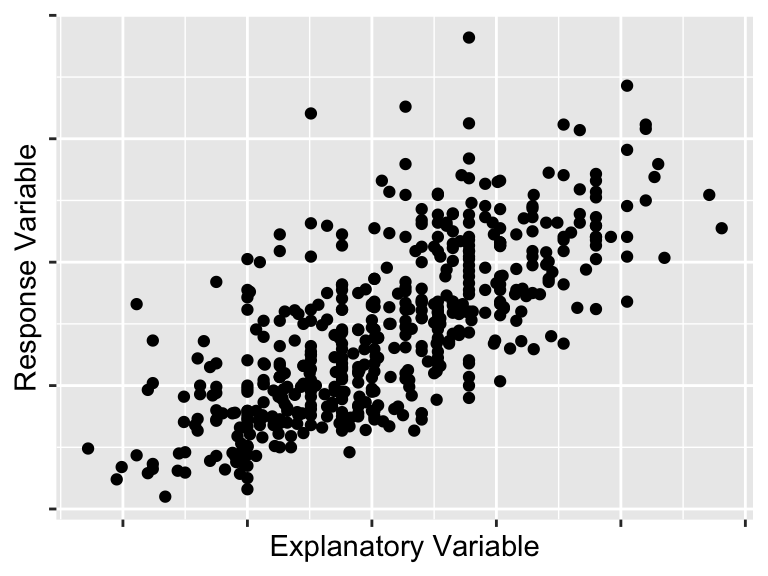

## Characterizing Relationships

- Form (e.g. linear, quadratic, non-linear)
- Direction (e.g. positive, negative)
- Strength (how much scatter/noise? sometimes characterized as weak or strong relationship.)
- Unusual Observations

## Your Turn

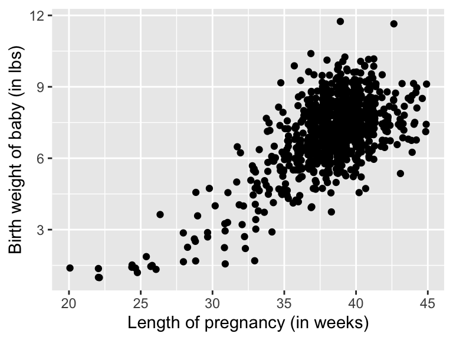

```r
ncbirths %>%
ggplot(aes(x = weeks, y = weight)) +
  geom_jitter() +
  labs(x = "Length of pregnancy (in weeks)",
       y = "Birth weight of baby (in lbs)")
```

How would your characterize this relationship?

- shape
- direction
- strength
- outliers

## Summarizing a Linear Relationship

- Correlation
  - Correlation coefficient between -1 and 1
  - Sign of the correlations shows direction
  - Magnitude of the correlation shows strength

```r
ncbirths %>%
  filter(is.na(weight) == FALSE,
         is.na(weeks) == FALSE) %>%
  summarize(correlation = cor(mage, weeks))
```

```
## # A tibble: 1 x 1
##   correlation
##         <dbl>
## 1     -0.0321
```

## Anscombe Correlations

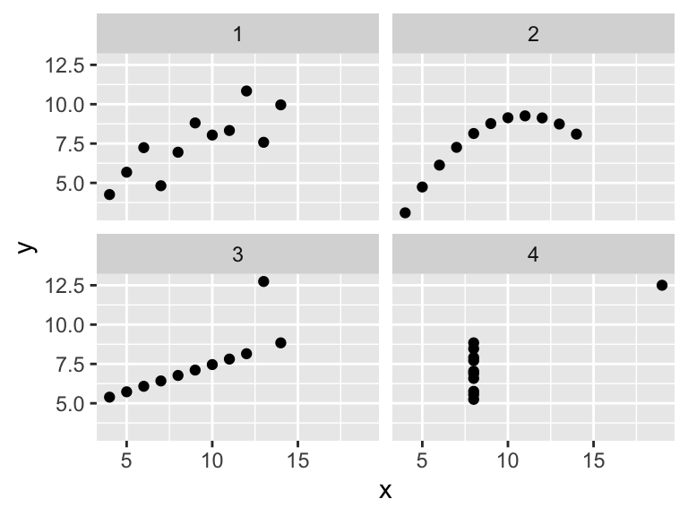

Four datasets, very different graphical presentations

- same mean and standard deviation in both \(x\) and \(y\)
- same correlation
- same regression line

**For which of these relationships is correlation a reasonable summary measure?**

## Fitting a Linear Model

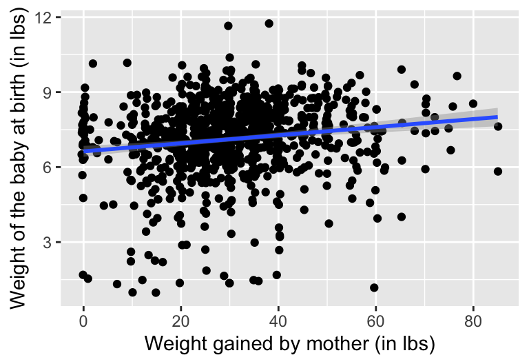

```r
ncbirths %>%
ggplot(aes(x = gained, y = weight)) +
  geom_jitter() +
  geom_smooth(method = "lm") +
  labs(x = "Weight gained by mother (in lbs)",
       y = "Weight of the baby at birth (in lbs)")

m1 <- lm(weight ~ gained, data = ncbirths)
```

## Interpretting a Linear Regression

```r
m1 <- lm(weight ~ weeks, data = ncbirths)
coef(m1)
```

```
## (Intercept)       weeks
##  -6.0952931   0.3443275
```

- Intercept: Expected **mean** value for \(y\), when \(x\) is 0
- Slope: Expected change in the **mean** of \(y\), when \(x\) is increased by 1 unit

**What do these interpretations look like for this relationship?**

## Model Diagnostics

- Linear relationship
- Independence of observations
- Normally distributed residuals
- Equal (constant) variance

## Independence

In all of the statistical models we encounter in this course we require for the observations in the data to be independent.

- Often the most crucial but also the most difficult to diagnose.
- Independence means that I should not be able to guess the \(y\) value for one observation based on knowing the \(y\) value of another observation.
- If there is an inherent grouping of observations, then independence may be violated.
  - Stock market prices over time
  - Geographical similarities
  - Biological conditions of family members
  - Repeated observations

## Linear Relationship

- Almost nothing you explore will look perfectly linear
- Be careful with relationships that have curvature
- Variable transformations can often help

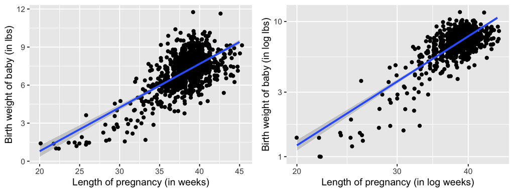

## Normally Distributed Residuals

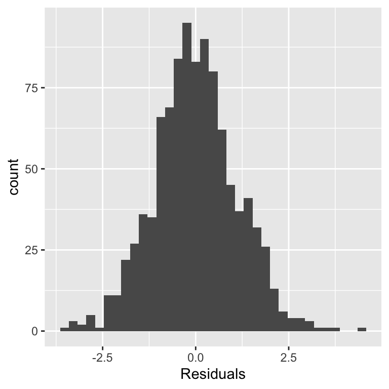

- Observations vary symmetrically around the least squares line, spreading out in a bell-shaped fashion.
- Less important than linearity or independence for a few reasons:
  - Least squares is an unbiased estimate of the true population model.
  - Larger sample sizes make the model more reliable.

## Equal Variance

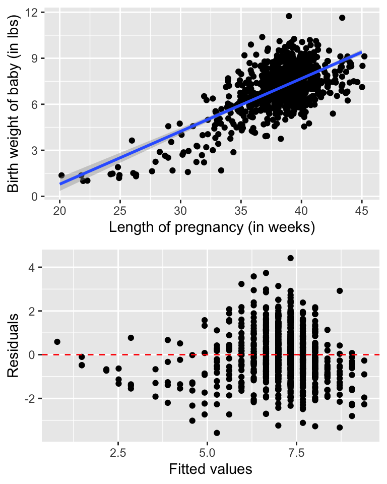

- The variability of points around the least squares line remains roughly constant.
- Data that exhibit non-equal variance across the range of x-values will have the potential to seriously mis-estimate the variability of the slope.

## Your Turn!

Let’s look at the relationship between the number of hospital visits of the mother and the weight of the baby.

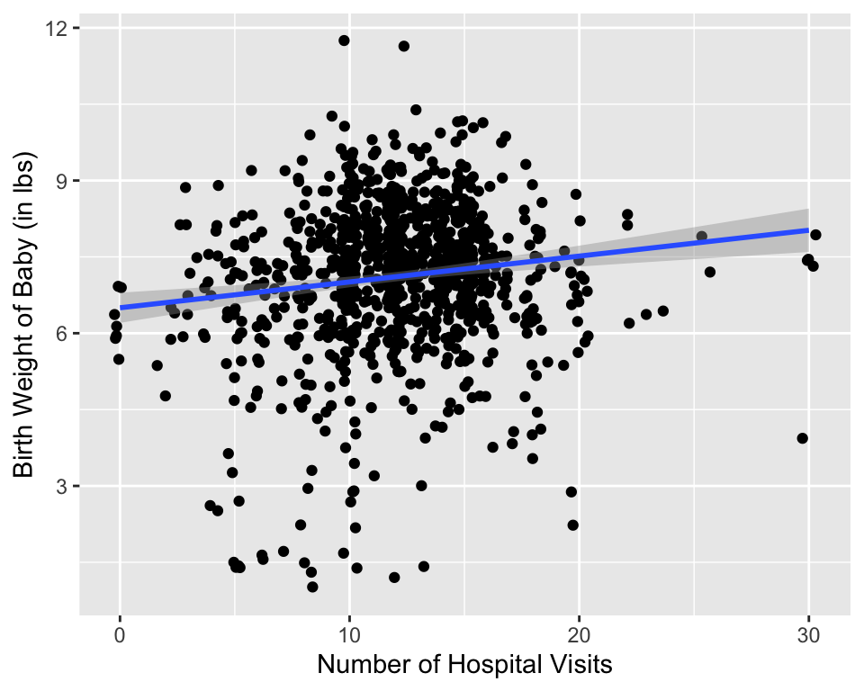

## Interpret the Model

```r
m2 <- lm(gained ~ visits, data = ncbirths)
```

[output not shown]